# Project 2

### **Objective:**

To understand and gain insights from a retail dataset by performing various exploratory data analyses, data visualization, and data modelling.

### **Dataset Columns:**

- **InvoiceNo:** Invoice number. A unique number per invoice.
- **StockCode:** Product code. A unique number per product.
- **Description:** Product description.
- **Quantity:** The number of products sold per invoice.
- **InvoiceDate:** The date and time of the invoice.
- **UnitPrice:** The price of one unit of the product.
- **CustomerID:** Customer identification number.
- **Country:** The country where the customer resides.

## 1. Data Preprocessing and Cleaning:

1.1. Import necessary libraries and read the dataset:

```python
#importing the necessary libraries
import pandas as pd
import numpy as np
import warnings
warnings.filterwarnings("ignore")

#reading the file
sales = pd.read_csv(r'D:\DAB\3nd - DAB\DAB303-25F-002 MARKETING ANALYTICS - PRATIK BEDI\Labs - W1\Week4_Lab\Sales_data.csv', encoding='ISO-8859-1')
sales
```

|  | InvoiceNo | StockCode | Description | Quantity | InvoiceDate | UnitPrice | CustomerID | Country |
| --- | --- | --- | --- | --- | --- | --- | --- | --- |
| 0 | 536365 | 85123A | WHITE HANGING HEART T-LIGHT HOLDER | 6 | 12/1/2010 8:26 | 2.55 | 17850.0 | United Kingdom |
| 1 | 536365 | 71053 | WHITE METAL LANTERN | 6 | 12/1/2010 8:26 | 3.39 | 17850.0 | United Kingdom |
| 2 | 536365 | 84406B | CREAM CUPID HEARTS COAT HANGER | 8 | 12/1/2010 8:26 | 2.75 | 17850.0 | United Kingdom |
| 3 | 536365 | 84029G | KNITTED UNION FLAG HOT WATER BOTTLE | 6 | 12/1/2010 8:26 | 3.39 | 17850.0 | United Kingdom |
| 4 | 536365 | 84029E | RED WOOLLY HOTTIE WHITE HEART. | 6 | 12/1/2010 8:26 | 3.39 | 17850.0 | United Kingdom |
| ... | ... | ... | ... | ... | ... | ... | ... | ... |
| 541904 | 581587 | 22613 | PACK OF 20 SPACEBOY NAPKINS | 12 | 12/9/2011 12:50 | 0.85 | 12680.0 | France |
| 541905 | 581587 | 22899 | CHILDREN'S APRON DOLLY GIRL | 6 | 12/9/2011 12:50 | 2.10 | 12680.0 | France |
| 541906 | 581587 | 23254 | CHILDRENS CUTLERY DOLLY GIRL | 4 | 12/9/2011 12:50 | 4.15 | 12680.0 | France |
| 541907 | 581587 | 23255 | CHILDRENS CUTLERY CIRCUS PARADE | 4 | 12/9/2011 12:50 | 4.15 | 12680.0 | France |
| 541908 | 581587 | 22138 | BAKING SET 9 PIECE RETROSPOT | 3 | 12/9/2011 12:50 | 4.95 | 12680.0 | France |

541909 rows × 8 columns

1.2. Display the top 10 rows of the dataframe:

```python
sales.head(10)
```

|  | InvoiceNo | StockCode | Description | Quantity | InvoiceDate | UnitPrice | CustomerID | Country |
| --- | --- | --- | --- | --- | --- | --- | --- | --- |
| 0 | 536365 | 85123A | WHITE HANGING HEART T-LIGHT HOLDER | 6 | 12/1/2010 8:26 | 2.55 | 17850.0 | United Kingdom |
| 1 | 536365 | 71053 | WHITE METAL LANTERN | 6 | 12/1/2010 8:26 | 3.39 | 17850.0 | United Kingdom |
| 2 | 536365 | 84406B | CREAM CUPID HEARTS COAT HANGER | 8 | 12/1/2010 8:26 | 2.75 | 17850.0 | United Kingdom |
| 3 | 536365 | 84029G | KNITTED UNION FLAG HOT WATER BOTTLE | 6 | 12/1/2010 8:26 | 3.39 | 17850.0 | United Kingdom |
| 4 | 536365 | 84029E | RED WOOLLY HOTTIE WHITE HEART. | 6 | 12/1/2010 8:26 | 3.39 | 17850.0 | United Kingdom |
| 5 | 536365 | 22752 | SET 7 BABUSHKA NESTING BOXES | 2 | 12/1/2010 8:26 | 7.65 | 17850.0 | United Kingdom |
| 6 | 536365 | 21730 | GLASS STAR FROSTED T-LIGHT HOLDER | 6 | 12/1/2010 8:26 | 4.25 | 17850.0 | United Kingdom |
| 7 | 536366 | 22633 | HAND WARMER UNION JACK | 6 | 12/1/2010 8:28 | 1.85 | 17850.0 | United Kingdom |
| 8 | 536366 | 22632 | HAND WARMER RED POLKA DOT | 6 | 12/1/2010 8:28 | 1.85 | 17850.0 | United Kingdom |
| 9 | 536367 | 84879 | ASSORTED COLOUR BIRD ORNAMENT | 32 | 12/1/2010 8:34 | 1.69 | 13047.0 | United Kingdom |

1.3. Check for missing values:

```python
sales.info()
sales.isnull().any()
sales.isnull().sum()
```

```
<class 'pandas.core.frame.DataFrame'>
RangeIndex: 541909 entries, 0 to 541908
Data columns (total 8 columns):
 #   Column       Non-Null Count   Dtype
---  ------       --------------   -----
 0   InvoiceNo    541909 non-null  object
 1   StockCode    541909 non-null  object
 2   Description  540455 non-null  object
 3   Quantity     541909 non-null  int64
 4   InvoiceDate  541909 non-null  object
 5   UnitPrice    541909 non-null  float64
 6   CustomerID   406829 non-null  float64
 7   Country      541909 non-null  object
dtypes: float64(2), int64(1), object(5)
memory usage: 33.1+ MB
```

```
InvoiceNo           0
StockCode           0
Description      1454
Quantity            0
InvoiceDate         0
UnitPrice           0
CustomerID     135080
Country             0
dtype: int64
```

```python
sales['CustomerID'].fillna(0, inplace=True)  # Using 0 as a placeholder
```

```python
sales['Description'] = sales['Description'].fillna('Unknown') # replace Description's null value with "Unknown"
```

```python
sales.info()
```

```
<class 'pandas.core.frame.DataFrame'>
RangeIndex: 541909 entries, 0 to 541908
Data columns (total 8 columns):
 #   Column       Non-Null Count   Dtype
---  ------       --------------   -----
 0   InvoiceNo    541909 non-null  object
 1   StockCode    541909 non-null  object
 2   Description  541909 non-null  object
 3   Quantity     541909 non-null  int64
 4   InvoiceDate  541909 non-null  object
 5   UnitPrice    541909 non-null  float64
 6   CustomerID   541909 non-null  float64
 7   Country      541909 non-null  object
dtypes: float64(2), int64(1), object(5)
memory usage: 33.1+ MB
```

1.4. Convert the InvoiceDate column to datetime format:

```python
sales['InvoiceDate'] = pd.to_datetime(sales['InvoiceDate'])
sales['InvoiceDate']
```

```
0        2010-12-01 08:26:00
1        2010-12-01 08:26:00
2        2010-12-01 08:26:00
3        2010-12-01 08:26:00
4        2010-12-01 08:26:00
                 ...
541904   2011-12-09 12:50:00
541905   2011-12-09 12:50:00
541906   2011-12-09 12:50:00
541907   2011-12-09 12:50:00
541908   2011-12-09 12:50:00
Name: InvoiceDate, Length: 541909, dtype: datetime64[ns]
```

1.5. Add a new column 'TotalPrice' to the dataframe which is the product of 'UnitPrice' and 'Quantity':

```python
sales['TotalPrice'] = sales['UnitPrice'] * sales['Quantity']
sales['TotalPrice']
```

```
0         15.30
1         20.34
2         22.00
3         20.34
4         20.34
          ...
541904    10.20
541905    12.60
541906    16.60
541907    16.60
541908    14.85
Name: TotalPrice, Length: 541909, dtype: float64
```

```python
sales.info()
sales.isnull().any()
sales.isnull().sum()
```

```
<class 'pandas.core.frame.DataFrame'>
RangeIndex: 541909 entries, 0 to 541908
Data columns (total 9 columns):
 #   Column       Non-Null Count   Dtype
---  ------       --------------   -----
 0   InvoiceNo    541909 non-null  object
 1   StockCode    541909 non-null  object
 2   Description  541909 non-null  object
 3   Quantity     541909 non-null  int64
 4   InvoiceDate  541909 non-null  datetime64[ns]
 5   UnitPrice    541909 non-null  float64
 6   CustomerID   541909 non-null  float64
 7   Country      541909 non-null  object
 8   TotalPrice   541909 non-null  float64
dtypes: datetime64[ns](1), float64(3), int64(1), object(4)
memory usage: 37.2+ MB
```

```
InvoiceNo      0
StockCode      0
Description    0
Quantity       0
InvoiceDate    0
UnitPrice      0
CustomerID     0
Country        0
TotalPrice     0
dtype: int64
```

```python
sales.head(10)
```

|  | InvoiceNo | StockCode | Description | Quantity | InvoiceDate | UnitPrice | CustomerID | Country | TotalPrice |
| --- | --- | --- | --- | --- | --- | --- | --- | --- | --- |
| 0 | 536365 | 85123A | WHITE HANGING HEART T-LIGHT HOLDER | 6 | 2010-12-01 08:26:00 | 2.55 | 17850.0 | United Kingdom | 15.30 |
| 1 | 536365 | 71053 | WHITE METAL LANTERN | 6 | 2010-12-01 08:26:00 | 3.39 | 17850.0 | United Kingdom | 20.34 |
| 2 | 536365 | 84406B | CREAM CUPID HEARTS COAT HANGER | 8 | 2010-12-01 08:26:00 | 2.75 | 17850.0 | United Kingdom | 22.00 |
| 3 | 536365 | 84029G | KNITTED UNION FLAG HOT WATER BOTTLE | 6 | 2010-12-01 08:26:00 | 3.39 | 17850.0 | United Kingdom | 20.34 |
| 4 | 536365 | 84029E | RED WOOLLY HOTTIE WHITE HEART. | 6 | 2010-12-01 08:26:00 | 3.39 | 17850.0 | United Kingdom | 20.34 |
| 5 | 536365 | 22752 | SET 7 BABUSHKA NESTING BOXES | 2 | 2010-12-01 08:26:00 | 7.65 | 17850.0 | United Kingdom | 15.30 |
| 6 | 536365 | 21730 | GLASS STAR FROSTED T-LIGHT HOLDER | 6 | 2010-12-01 08:26:00 | 4.25 | 17850.0 | United Kingdom | 25.50 |
| 7 | 536366 | 22633 | HAND WARMER UNION JACK | 6 | 2010-12-01 08:28:00 | 1.85 | 17850.0 | United Kingdom | 11.10 |
| 8 | 536366 | 22632 | HAND WARMER RED POLKA DOT | 6 | 2010-12-01 08:28:00 | 1.85 | 17850.0 | United Kingdom | 11.10 |
| 9 | 536367 | 84879 | ASSORTED COLOUR BIRD ORNAMENT | 32 | 2010-12-01 08:34:00 | 1.69 | 13047.0 | United Kingdom | 54.08 |

## 2. Exploratory Data Analysis:

2.1. How many unique products are there in the dataset?

```python
print('Total unique products:', sales['StockCode'].nunique())
```

```
Total unique products: 4070
```

2.2. Which are the top 10 products (using StockCode) sold by quantity?

```python
sales.groupby('StockCode')['Quantity'].sum().sort_values(ascending=False).head(10).reset_index()
```

|  | StockCode | Quantity |
| --- | --- | --- |
| 0 | 22197 | 56450 |
| 1 | 84077 | 53847 |
| 2 | 85099B | 47363 |
| 3 | 85123A | 38830 |
| 4 | 84879 | 36221 |
| 5 | 21212 | 36039 |
| 6 | 23084 | 30646 |
| 7 | 22492 | 26437 |
| 8 | 22616 | 26315 |
| 9 | 21977 | 24753 |

2.3. How many unique customers are there in the dataset?

```python
print('Total Unique Customers: ', sales['CustomerID'].nunique())
```

```
Total Unique Customers:  4373
```

2.4. Which country has the maximum number of unique customers?

```python
print(sales.groupby('Country')['CustomerID'].nunique().idxmax())
print(sales.groupby('Country')['CustomerID'].nunique().max())
```

[output not shown]

2.5. Visualize the distribution of 'TotalPrice' using a histogram.

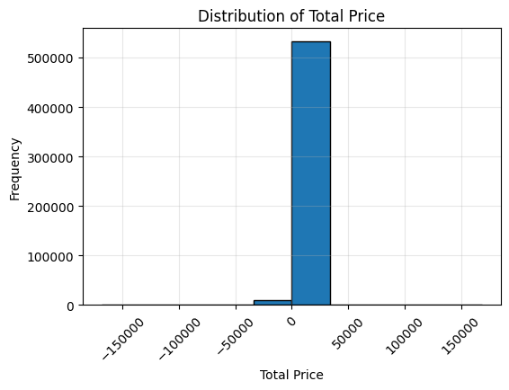

```python
import matplotlib.pyplot as plt

sales['TotalPrice'].plot(kind='hist', bins=10, edgecolor='black', figsize=(6,4))
plt.xlabel("Total Price")
plt.ylabel("Frequency")
plt.title("Distribution of Total Price")
plt.xticks(rotation=45)
plt.grid(alpha=0.3)
plt.show()
```

Key Insights:

- The distribution of Total Price is highly right-skewed, meaning most transaction values are concentrated around lower ranges, while a small number of extreme values (outliers) extend far to the right.
- There are also some negative values, which likely represent product returns or refunds.
- The majority of invoices fall within a narrow price range, suggesting typical purchases are small, while high-value transactions are rare but impactful.

## 3. Data Aggregation:

3.1. Compute the total sales (TotalPrice) per country.

```python
sales.groupby('Country').agg(TotalSales=('TotalPrice','sum'))\
    .sort_values(by='TotalSales', ascending=False).reset_index()
```

|  | Country | TotalSales |
| --- | --- | --- |
| 0 | United Kingdom | 8187806.364 |
| 1 | Netherlands | 284661.540 |
| 2 | EIRE | 263276.820 |
| 3 | Germany | 221698.210 |
| 4 | France | 197403.900 |
| 5 | Australia | 137077.270 |
| 6 | Switzerland | 56385.350 |
| 7 | Spain | 54774.580 |
| 8 | Belgium | 40910.960 |
| 9 | Sweden | 36595.910 |
| 10 | Japan | 35340.620 |
| 11 | Norway | 35163.460 |
| 12 | Portugal | 29367.020 |
| 13 | Finland | 22326.740 |
| 14 | Channel Islands | 20086.290 |
| 15 | Denmark | 18768.140 |
| 16 | Italy | 16890.510 |
| 17 | Cyprus | 12946.290 |
| 18 | Austria | 10154.320 |
| 19 | Hong Kong | 10117.040 |
| 20 | Singapore | 9120.390 |
| 21 | Israel | 7907.820 |
| 22 | Poland | 7213.140 |
| 23 | Unspecified | 4749.790 |
| 24 | Greece | 4710.520 |
| 25 | Iceland | 4310.000 |
| 26 | Canada | 3666.380 |
| 27 | Malta | 2505.470 |
| 28 | United Arab Emirates | 1902.280 |
| 29 | USA | 1730.920 |
| 30 | Lebanon | 1693.880 |
| 31 | Lithuania | 1661.060 |
| 32 | European Community | 1291.750 |
| 33 | Brazil | 1143.600 |
| 34 | RSA | 1002.310 |
| 35 | Czech Republic | 707.720 |
| 36 | Bahrain | 548.400 |
| 37 | Saudi Arabia | 131.170 |

3.2. Identify the month in which the sales were highest.

```python
sales.groupby(sales['InvoiceDate'].dt.strftime('%b'))\
    .agg(TotalSales=('TotalPrice','sum'))\
        .sort_values(by='TotalSales', ascending=False).head(1)\
        .reset_index()
```

|  | InvoiceDate | TotalSales |
| --- | --- | --- |
| 0 | Nov | 1461756.25 |

3.3. Compute the average unit price per product.

```python
sales.groupby('StockCode').agg(AverageUnitPrice=('UnitPrice', 'mean'))\
    .sort_values(by='AverageUnitPrice', ascending=False)\
    .reset_index()
```

|  | StockCode | AverageUnitPrice |
| --- | --- | --- |
| 0 | AMAZONFEE | 7324.784706 |
| 1 | CRUK | 495.839375 |
| 2 | M | 375.566392 |
| 3 | DOT | 290.495859 |
| 4 | BANK CHARGES | 202.855162 |
| ... | ... | ... |
| 4065 | 84967A | 0.000000 |
| 4066 | 72038P | 0.000000 |
| 4067 | 84797B | 0.000000 |
| 4068 | DCGS0068 | 0.000000 |
| 4069 | B | -3687.353333 |

4070 rows × 2 columns

3.4. Compute the total quantity sold per customer. There are 4373 Customers

```python
sales.groupby('CustomerID').agg(TotalQuantity=('Quantity', 'sum'))\
    .sort_values(by='TotalQuantity', ascending=False)\
    .reset_index()
```

|  | CustomerID | TotalQuantity |
| --- | --- | --- |
| 0 | 0.0 | 269562 |
| 1 | 14646.0 | 196719 |
| 2 | 12415.0 | 77242 |
| 3 | 14911.0 | 77180 |
| 4 | 17450.0 | 69029 |
| ... | ... | ... |
| 4368 | 16252.0 | -158 |
| 4369 | 16742.0 | -189 |
| 4370 | 14213.0 | -244 |
| 4371 | 15823.0 | -283 |
| 4372 | 16546.0 | -303 |

4373 rows × 2 columns

## 4. Data Visualization:

4.1. Create a bar chart showcasing the sales (TotalPrice) for each country.

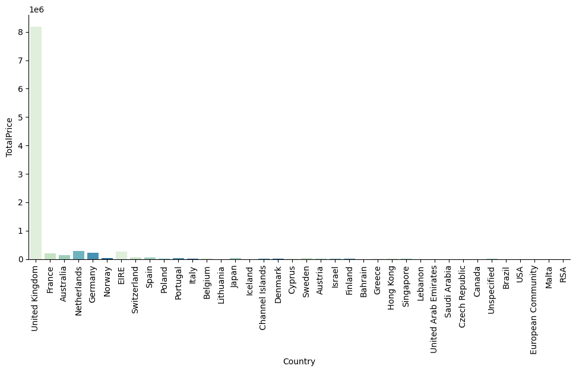

```python
import seaborn as sns
sns.catplot(x='Country', y='TotalPrice', data=sales, kind='bar',palette=sns.color_palette('GnBu'), errorbar=None, aspect=2, estimator='sum')
plt.xticks(rotation=90)
plt.show()
```

Key Insights:

- United Kingdom overwhelmingly dominates total revenue, contributing far more than any other country.
- Other countries such as Netherlands, Germany, France, and Australia show revenue contributions but are significantly lower compared to the UK.
- Countries outside the top 5 contribute only marginal amounts, indicating high geographical concentration of sales.

4.2. Plot a line graph to showcase the trend of sales over time.

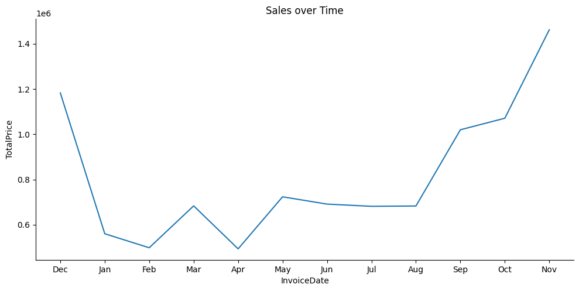

```python
sns.relplot(x=sales['InvoiceDate'].dt.strftime('%b'),
            y='TotalPrice', data=sales, kind='line',
            aspect=2, estimator='sum', errorbar=None)
plt.title('Sales over Time')
plt.show()
```

Key Insights: Strong seasonality is observed:

- Sales are highest in November and December, suggesting strong demand during the holiday season.
- January and February show a significant drop, which is typical after peak festive purchases.
- From April to August, sales remain relatively stable but at a moderate level.
- A noticeable growth trend begins in September, steadily increasing toward year-end.

4.3. Use a scatter plot to visualize the relationship between UnitPrice and Quantity.

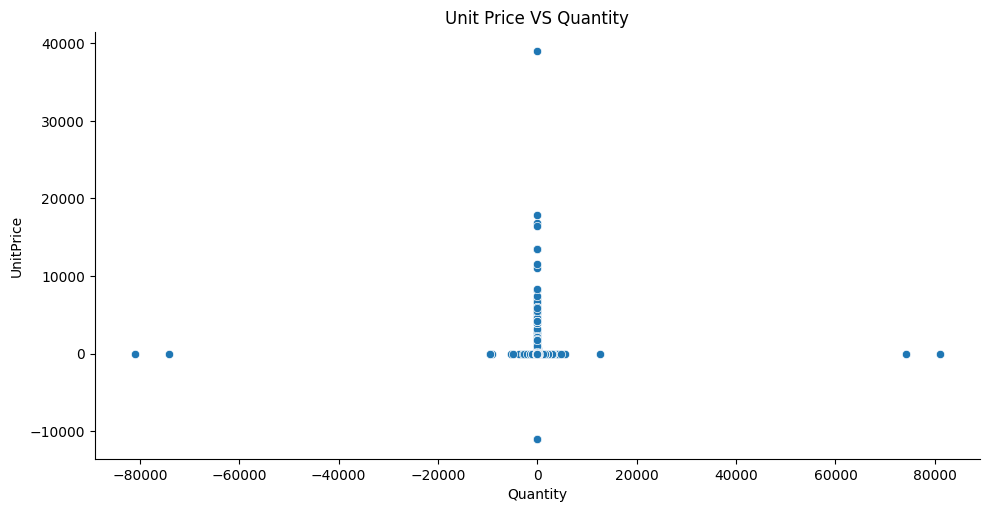

```python
sns.relplot(y='UnitPrice', x='Quantity', data=sales, kind='scatter', aspect=2)
plt.title('Unit Price VS Quantity')
plt.show()
```

Key Insights:

- Weak correlation: Unit prices fluctuate independently of quantity, with no clear trend.
- Data anomalies: Negative values indicate potential refunds/returns.
- Outliers: High prices at low quantities suggest premium or erroneous entries.

4.4. Plot a heatmap to display the correlation between numeric columns.

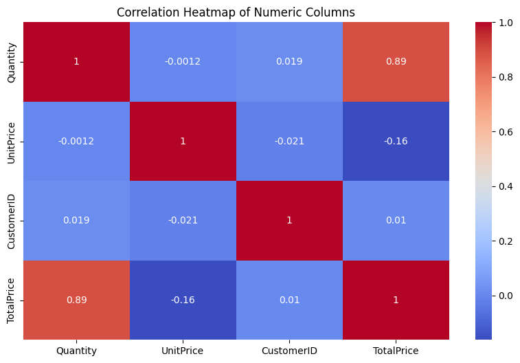

```python
import seaborn as sns
# Select only the numeric columns
numeric_df = sales.select_dtypes(include='number')

# Compute the correlation matrix for numeric columns
corr_matrix = numeric_df.corr()

# Create the heatmap
plt.figure(figsize=(10,6))
sns.heatmap(corr_matrix, annot=True, cmap='coolwarm')

# Add titles and labels
plt.title('Correlation Heatmap of Numeric Columns')

plt.show()
```

Key Insights:

- The value of 0.89 indicates a very strong, positive correlation between Quantity and TotalPrice. This makes sense, as the more units purchased, the higher the total price paid (Total Price).
- The other variables have weak or very weak correlations with each other. For example,
- UnitPrice has a weak negative correlation (−0.16) with TotalPrice.
- CustomerID has almost zero correlation with all other numbers, for example: 0.01 with TotalPrice. This is expected, as - - CustomerID is an identifier and should not have a linear relationship with quantity transactions.

## 5. Advanced Analysis:

5.1. Identify potential outliers in the dataset for the Quantity and UnitPrice columns using appropriate visualization techniques.

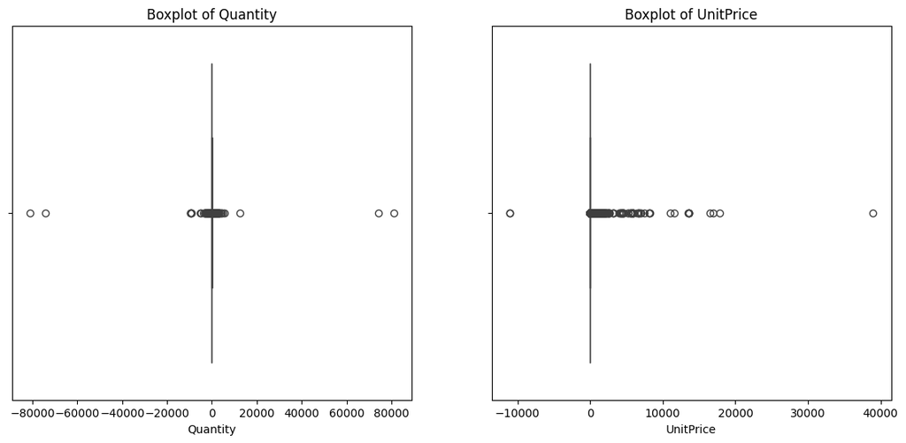

```python
# Set up the matplotlib figure
plt.figure(figsize=(14,6))

# Create subplots for Quantity and UnitPrice
plt.subplot(1,2,1)
sns.boxplot(data=sales, x='Quantity')
plt.title('Boxplot of Quantity')

plt.subplot(1,2,2)
sns.boxplot(data=sales, x='UnitPrice')
plt.title('Boxplot of UnitPrice')

plt.show()
```

5.2. Segment customers based on their purchase history (Consider factors like total purchases, frequency of purchases, etc.).

```python
sales.head(3)
```

|  | InvoiceNo | StockCode | Description | Quantity | InvoiceDate | UnitPrice | CustomerID | Country | TotalPrice |
| --- | --- | --- | --- | --- | --- | --- | --- | --- | --- |
| 0 | 536365 | 85123A | WHITE HANGING HEART T-LIGHT HOLDER | 6 | 2010-12-01 08:26:00 | 2.55 | 17850.0 | United Kingdom | 15.30 |
| 1 | 536365 | 71053 | WHITE METAL LANTERN | 6 | 2010-12-01 08:26:00 | 3.39 | 17850.0 | United Kingdom | 20.34 |
| 2 | 536365 | 84406B | CREAM CUPID HEARTS COAT HANGER | 8 | 2010-12-01 08:26:00 | 2.75 | 17850.0 | United Kingdom | 22.00 |

```python
# Recency: How recently did the customer make a purchase?
current_date = sales['InvoiceDate'].max() + pd.DateOffset(1)
recency = sales.groupby('CustomerID')['InvoiceDate'].apply(lambda x: (current_date - x.max()).days)

# Ferequency: How many times did the customer make a purchase?
frequency = sales.groupby('CustomerID')['InvoiceNo'].nunique()

# Monetary: Total spending by the customer
monetary = sales.groupby('CustomerID')['TotalPrice'].sum()

# Combine RFM metrics into a single DataFrame
rfm = pd.DataFrame({'Recency': recency, 'Frequency': frequency, 'Monetary': monetary})

rfm.head(5)
```

| CustomerID | Recency | Frequency | Monetary |
| --- | --- | --- | --- |
| 0.0 | 1 | 3710 | 1447682.12 |
| 12346.0 | 326 | 2 | 0.00 |
| 12347.0 | 2 | 7 | 4310.00 |
| 12348.0 | 75 | 4 | 1797.24 |
| 12349.0 | 19 | 1 | 1757.55 |

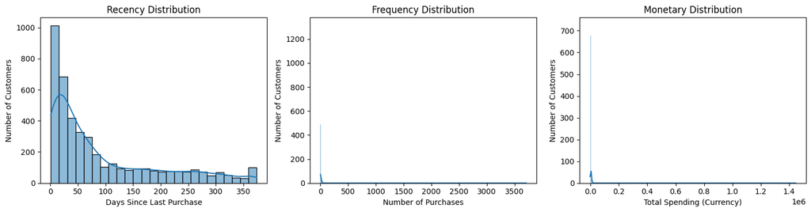

```python
import matplotlib.pyplot as plt
import seaborn as sns

plt.figure(figsize=(15, 4))

# Recency (Calculated in days)
plt.subplot(1, 3, 1)
sns.histplot(rfm['Recency'], kde=True)
plt.title('Recency Distribution')
plt.xlabel('Days Since Last Purchase')
plt.ylabel('Number of Customers')

# Frequency (Number of purchases)
plt.subplot(1, 3, 2)
sns.histplot(rfm['Frequency'], kde=True)
plt.title('Frequency Distribution')
plt.xlabel('Number of Purchases')
plt.ylabel('Number of Customers')

# Monetary (Total expenditure)
plt.subplot(1, 3, 3)
sns.histplot(rfm['Monetary'], kde=True)
plt.title('Monetary Distribution')
plt.xlabel('Total Spending (Currency)')
plt.ylabel('Number of Customers')

plt.tight_layout()
plt.show()
```

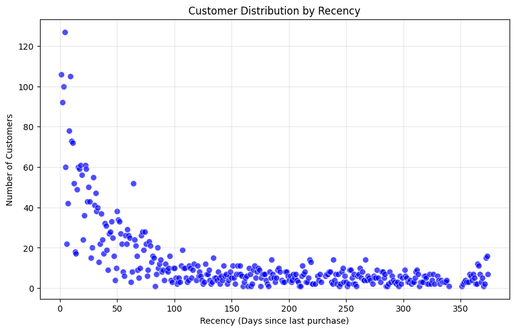

```python
import matplotlib.pyplot as plt
import seaborn as sns

# 1. Calculate the number of customers by Recency
recency_count = rfm.groupby('Recency').size().reset_index(name='CustomerCount')

# 2. scatter plot
plt.figure(figsize=(10,6))
sns.scatterplot(x='Recency', y='CustomerCount', data=recency_count, color='blue', s=50, alpha=0.7)
plt.title('Customer Distribution by Recency')
plt.xlabel('Recency (Days since last purchase)')
plt.ylabel('Number of Customers')
plt.grid(alpha=0.3)
plt.show()
```

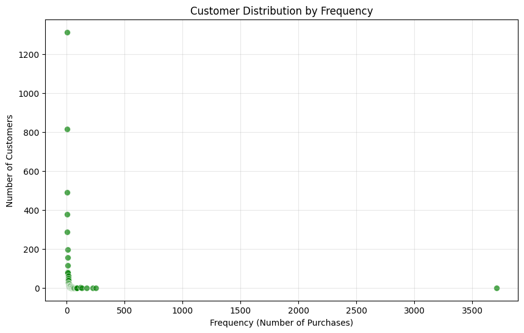

```python
# 1. Calculate the number of customers by Frequency
frequency_count = rfm.groupby('Frequency').size().reset_index(name='CustomerCount')

# 2. scatter plot
plt.figure(figsize=(10,6))
sns.scatterplot(x='Frequency', y='CustomerCount', data=frequency_count, color='green', s=50, alpha=0.7)
plt.title('Customer Distribution by Frequency')
plt.xlabel('Frequency (Number of Purchases)')
plt.ylabel('Number of Customers')
plt.grid(alpha=0.3)
plt.show()
```

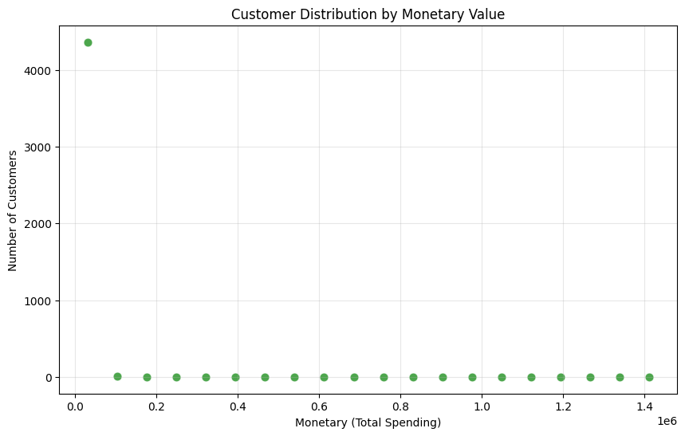

```python
bins = 20
rfm['MonetaryBin'] = pd.cut(rfm['Monetary'], bins=bins)

monetary_count = rfm.groupby('MonetaryBin').size().reset_index(name='CustomerCount')

monetary_count['MonetaryMid'] = monetary_count['MonetaryBin'].apply(lambda x: x.mid)

# scatter plot
plt.figure(figsize=(10,6))
sns.scatterplot(x='MonetaryMid', y='CustomerCount', data=monetary_count, color='green', s=60, alpha=0.7)
plt.title('Customer Distribution by Monetary Value')
plt.xlabel('Monetary (Total Spending)')
plt.ylabel('Number of Customers')
plt.grid(alpha=0.3)
plt.show()
```

5.3. For the top 5 products (by quantity sold), visualize their monthly sales trend.

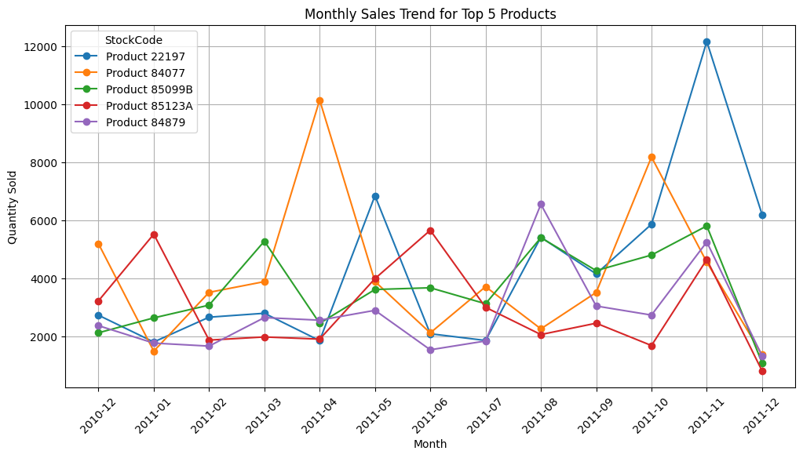

```python
# Identify the top 5 products by quantity sold
top_products = sales.groupby('StockCode')['Quantity'].sum().nlargest(5).index

# Create a 'Month' column by extracting the month and year from 'InvoiceDate'
sales['MonthYear'] = sales['InvoiceDate'].dt.to_period('M')

# Filter the dataset for the top 5 products
top_products_df = sales[sales['StockCode'].isin(top_products)]

# Group by 'StockCode' and 'MonthYear' and sum the quantity
monthly_sales = top_products_df.groupby(['StockCode', 'MonthYear'])['Quantity'].sum().unstack()
monthly_sales

# Plot the monthly sales trend for the top 5 products
plt.figure(figsize=(12,6))

# Plot each product's monthly trend
for product in top_products:
    plt.plot(monthly_sales.columns.astype(str), monthly_sales.loc[product], marker='o', label=f'Product {product}')

# Add labels and title
plt.title('Monthly Sales Trend for Top 5 Products')
plt.xlabel('Month')
plt.ylabel('Quantity Sold')
plt.xticks(rotation=45)
plt.legend(title='StockCode')
plt.grid(True)

plt.show()
```

# Advanced Machine Learning Analysis with Retail Dataset

## 6. Feature Engineering:

6.1 Extract 'Year', 'Month', 'Day', and 'Hour' from the InvoiceDate and create separate columns for each.

```python
sales['Year'] = sales['InvoiceDate'].dt.year
sales['Month'] = sales['InvoiceDate'].dt.month
sales['Day'] = sales['InvoiceDate'].dt.day
sales['Hour'] = sales['InvoiceDate'].dt.hour

sales.head(2)
```

|  | InvoiceNo | StockCode | Description | Quantity | InvoiceDate | UnitPrice | CustomerID | Country | TotalPrice | MonthYear | Year | Month | Day | Hour |
| --- | --- | --- | --- | --- | --- | --- | --- | --- | --- | --- | --- | --- | --- | --- |
| 0 | 536365 | 85123A | WHITE HANGING HEART T-LIGHT HOLDER | 6 | 2010-12-01 08:26:00 | 2.55 | 17850.0 | United Kingdom | 15.30 | 2010-12 | 2010 | 12 | 1 | 8 |
| 1 | 536365 | 71053 | WHITE METAL LANTERN | 6 | 2010-12-01 08:26:00 | 3.39 | 17850.0 | United Kingdom | 20.34 | 2010-12 | 2010 | 12 | 1 | 8 |

6.2 Create a new column `'ReturnFlag'` where if `'Quantity'` is less than zero, it's 1, otherwise 0. This will indicate whether an item was returned.

```python
sales['ReturnFlag'] = (sales['Quantity']<0).astype(int)

sales.head(2)
```

|  | InvoiceNo | StockCode | Description | Quantity | InvoiceDate | UnitPrice | CustomerID | Country | TotalPrice | MonthYear | Year | Month | Day | Hour | ReturnFlag |
| --- | --- | --- | --- | --- | --- | --- | --- | --- | --- | --- | --- | --- | --- | --- | --- |
| 0 | 536365 | 85123A | WHITE HANGING HEART T-LIGHT HOLDER | 6 | 2010-12-01 08:26:00 | 2.55 | 17850.0 | United Kingdom | 15.30 | 2010-12 | 2010 | 12 | 1 | 8 | 0 |
| 1 | 536365 | 71053 | WHITE METAL LANTERN | 6 | 2010-12-01 08:26:00 | 3.39 | 17850.0 | United Kingdom | 20.34 | 2010-12 | 2010 | 12 | 1 | 8 | 0 |

## 7. Customer Segmentation using Clustering:

7.1. Create a matrix RFM (Recency, Frequency, Monetary) for each customer:

- Recency: Number of days since the last purchase
- Frequency: Number of purchases
- Monetary: Total money spent

```python
# Step 1: Set current date (this can be the maximum invoice date in the dataset + 1 day)
current_date = sales['InvoiceDate'].max() + pd.DateOffset(1)

# Step 2: Recency - Number of days since last purchase
recency = sales.groupby('CustomerID')['InvoiceDate'].max().apply(lambda x: (current_date - x).days)

# Step 3: Frequency - Number of purchases made by the customer (count of unique InvoiceNo per CustomerID)
frequency = sales.groupby('CustomerID')['InvoiceNo'].nunique()

# Step 4: Monetary - Total money spent (sum of TotalPrice per CustomerID)
monetary = sales.groupby('CustomerID')['TotalPrice'].sum()

# Step 5: Combine Recency, Frequency, and Monetary into a single DataFrame (RFM Matrix)
rfm = pd.DataFrame({
    'Recency': recency,
    'Frequency': frequency,
    'Monetary': monetary
})

rfm.head(5)
```

| CustomerID | Recency | Frequency | Monetary |
| --- | --- | --- | --- |
| 0.0 | 1 | 3710 | 1447682.12 |
| 12346.0 | 326 | 2 | 0.00 |
| 12347.0 | 2 | 7 | 4310.00 |
| 12348.0 | 75 | 4 | 1797.24 |
| 12349.0 | 19 | 1 | 1757.55 |

7.2. Normalize the RFM matrix with StandardScaler:

```python
from sklearn.preprocessing import StandardScaler

# Initialize the StandardScaler
scaler = StandardScaler()

# Normalize the RFM values
rfm_normalized = scaler.fit_transform(rfm)

# Create a new DataFrame with the normalized values
rfm_normalized_df = pd.DataFrame(rfm_normalized, columns=['Recency', 'Frequency', 'Monetary'])

rfm_normalized_df.head(5)
```

|  | Recency | Frequency | Monetary |
| --- | --- | --- | --- |
| 0 | -0.903471 | 65.221449 | 61.892754 |
| 1 | 2.322278 | -0.069071 | -0.095447 |
| 2 | -0.893545 | 0.018969 | 0.089103 |
| 3 | -0.168992 | -0.033855 | -0.018491 |
| 4 | -0.724814 | -0.086679 | -0.020190 |

7.3. Use KMeans clustering to segment customers into different groups. Determine the optimal number of clusters using the Elbow method.

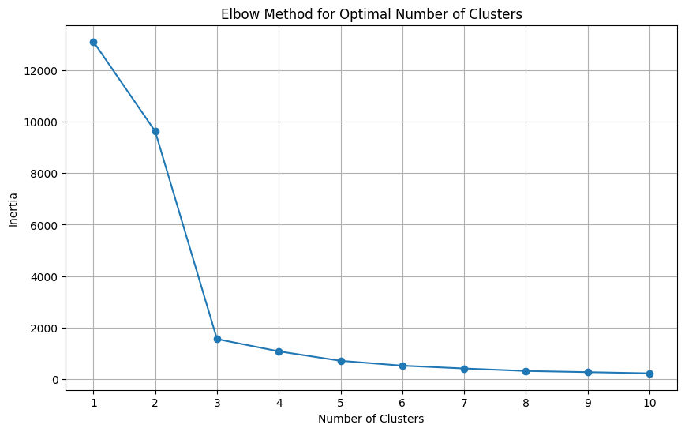

```python
from sklearn.cluster import KMeans

# Determine the optimal number of clusters using the Elbow method
inertia = []  # List to hold the inertia values

# Test a range of cluster numbers
cluster_range = range(1, 11)  # Change the range if needed

for n_clusters in cluster_range:
    kmeans = KMeans(n_clusters=n_clusters, random_state=42)
    kmeans.fit(rfm_normalized)
    inertia.append(kmeans.inertia_)

# Plotting the Elbow Curve
plt.figure(figsize=(10, 6))
plt.plot(cluster_range, inertia, marker='o')
plt.title('Elbow Method for Optimal Number of Clusters')
plt.xlabel('Number of Clusters')
plt.ylabel('Inertia')
plt.xticks(cluster_range)
plt.grid()

plt.show()
```

The optimal number of customer segments (clusters) suggested by the Elbow Method is 3, or possibly 4, as increasing the number of segments further provides minimal incremental benefit to data grouping accuracy.

Business Implication K=3 is the optimal point for simplifying marketing strategy and maximizing segmentation efficiency.

The company should start by developing 3 core customer profiles to focus resources and budget.

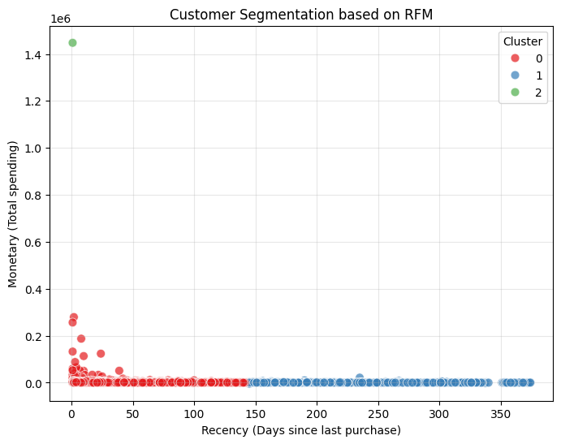

```python
from sklearn.preprocessing import StandardScaler
from sklearn.cluster import KMeans

# 1. Chọn các cột RFM
rfm_features = rfm[['Recency', 'Frequency', 'Monetary']]

# 2. Chuẩn hóa dữ liệu
scaler = StandardScaler()
rfm_scaled = scaler.fit_transform(rfm_features)

# 3. Áp dụng K-Means clustering (3 nhóm ví dụ)
kmeans = KMeans(n_clusters=3, random_state=42)
rfm['Cluster'] = kmeans.fit_predict(rfm_scaled)

# 4. Vẽ scatter plot: Recency vs Monetary
plt.figure(figsize=(8,6))
sns.scatterplot(x='Recency', y='Monetary', hue='Cluster', data=rfm, palette='Set1', s=60, alpha=0.7)
plt.title('Customer Segmentation based on RFM')
plt.xlabel('Recency (Days since last purchase)')
plt.ylabel('Monetary (Total spending)')
plt.legend(title='Cluster')
plt.grid(alpha=0.3)
plt.show()
```

The majority of the customer base (Cluster 0 & 1) are low spenders, but they are clearly differentiated by their recency: Cluster 0 is the recently active group (needs increased spending), while Cluster 1 is the dormant group (needs reactivation). Cluster 2 is a single VIP customer who needs special care.

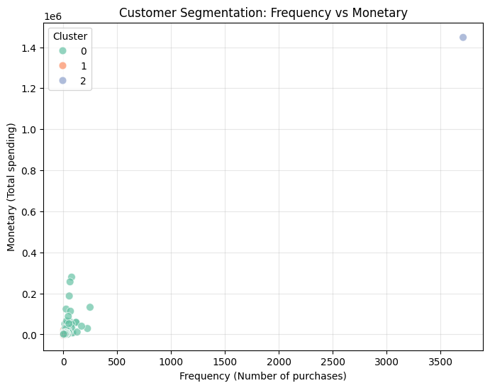

```python
# Frequency vs Monetary
plt.figure(figsize=(8,6))
sns.scatterplot(x='Frequency', y='Monetary', hue='Cluster', data=rfm, palette='Set2', s=60, alpha=0.7)
plt.title('Customer Segmentation: Frequency vs Monetary')
plt.xlabel('Frequency (Number of purchases)')
plt.ylabel('Monetary (Total spending)')
plt.legend(title='Cluster')
plt.grid(alpha=0.3)
plt.show()
```

- Isolated VIP Outlier: Cluster 2 (Light Purple) represents a single outlier customer with Extremely High Frequency and Monetary (≈3,700 purchases; ≈1.4M spending).
- Low-Value Mass: Cluster 0 and Cluster 1 (Mint & Light Orange) constitute the vast majority of customers, clustered in the bottom-left corner with Very Low Frequency and Monetary.
- Business Action: Focus on strategies to increase purchase frequency and average spending for Cluster 0/1 to improve overall revenue.

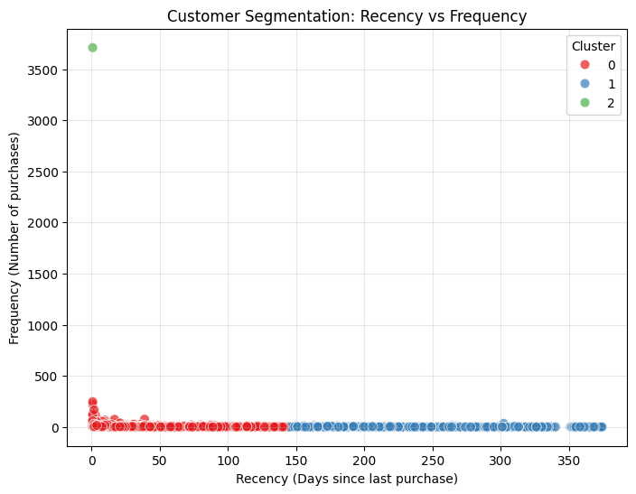

```python
# Recency vs Frequency
plt.figure(figsize=(8,6))
sns.scatterplot(x='Recency', y='Frequency', hue='Cluster', data=rfm, palette='Set1', s=60, alpha=0.7)
plt.title('Customer Segmentation: Recency vs Frequency')
plt.xlabel('Recency (Days since last purchase)')
plt.ylabel('Frequency (Number of purchases)')
plt.legend(title='Cluster')
plt.grid(alpha=0.3)
plt.show()
```

- Isolated Star Customer: Cluster 2 (Green) is a single outlier customer with Very Low Recency (most recent purchase) and Extremely High Frequency (≈3,700 purchases).
- Segmentation by Recency: The two largest groups (Cluster 0 and Cluster 1) both have Very Low Frequency (≈0−150 purchases). The key differentiator is Recency.
- Cluster 0 (Red): Recently Active (low Recency). Focus on driving repeat purchases.
- Cluster 1 (Blue): Lapsed/At-Risk (high Recency). Focus on re-activation campaigns.
- Business Action: Prioritize converting Cluster 0 into repeat buyers before they become Cluster 1.

## 8. Predictive Analytics:

```python
sales.head(5)
```

|  | InvoiceNo | StockCode | Description | Quantity | InvoiceDate | UnitPrice | CustomerID | Country | TotalPrice | MonthYear | Year | Month | Day | Hour | ReturnFlag |
| --- | --- | --- | --- | --- | --- | --- | --- | --- | --- | --- | --- | --- | --- | --- | --- |
| 0 | 536365 | 85123A | WHITE HANGING HEART T-LIGHT HOLDER | 6 | 2010-12-01 08:26:00 | 2.55 | 17850.0 | United Kingdom | 15.30 | 2010-12 | 2010 | 12 | 1 | 8 | 0 |
| 1 | 536365 | 71053 | WHITE METAL LANTERN | 6 | 2010-12-01 08:26:00 | 3.39 | 17850.0 | United Kingdom | 20.34 | 2010-12 | 2010 | 12 | 1 | 8 | 0 |
| 2 | 536365 | 84406B | CREAM CUPID HEARTS COAT HANGER | 8 | 2010-12-01 08:26:00 | 2.75 | 17850.0 | United Kingdom | 22.00 | 2010-12 | 2010 | 12 | 1 | 8 | 0 |
| 3 | 536365 | 84029G | KNITTED UNION FLAG HOT WATER BOTTLE | 6 | 2010-12-01 08:26:00 | 3.39 | 17850.0 | United Kingdom | 20.34 | 2010-12 | 2010 | 12 | 1 | 8 | 0 |
| 4 | 536365 | 84029E | RED WOOLLY HOTTIE WHITE HEART. | 6 | 2010-12-01 08:26:00 | 3.39 | 17850.0 | United Kingdom | 20.34 | 2010-12 | 2010 | 12 | 1 | 8 | 0 |

8.1. Can you predict if a customer will return an item? Use the 'ReturnFlag' as the target variable and build a classification model.

- Split data into training and test sets.
- Use features like 'UnitPrice', 'Quantity', etc.
- Evaluate model accuracy, precision, recall, and F1-score.

```python
# 1. Import library
import pandas as pd
from sklearn.model_selection import train_test_split
from sklearn.ensemble import RandomForestClassifier
from sklearn.metrics import accuracy_score, precision_score, recall_score, f1_score, classification_report
import matplotlib.pyplot as plt

# 2. Select features
numeric_features = ['UnitPrice', 'TotalPrice', 'Hour']
categorical_features = ['StockCode', 'Country']

# One-hot encoding cho categorical features
X_cat = pd.get_dummies(sales[categorical_features], drop_first=True)
X_num = sales[numeric_features]
X = pd.concat([X_num, X_cat], axis=1)

# Target
y = sales['ReturnFlag']
```

```python
# 3. Split train/test data
X_train, X_test, y_train, y_test = train_test_split(X, y, test_size=0.2, random_state=42, stratify=y)

# 4. Create và fit Random Forest model
model = RandomForestClassifier(n_estimators=20, random_state=42)
model.fit(X_train, y_train)

# 5. Predict on test set
y_pred = model.predict(X_test)
```

```python
# 6. Evaluate model
accuracy = accuracy_score(y_test, y_pred)
precision = precision_score(y_test, y_pred, pos_label=1)
recall = recall_score(y_test, y_pred, pos_label=1)
f1 = f1_score(y_test, y_pred, pos_label=1)

print("Accuracy:", round(accuracy, 4))
print("Precision:", round(precision, 4))
print("Recall:", round(recall, 4))
print("F1-score:", round(f1, 4))
print("\nClassification Report:\n", classification_report(y_test, y_pred))
```

```
Accuracy: 0.9982
Precision: 0.9443
Recall: 0.9661
F1-score: 0.9551

Classification Report:
               precision    recall  f1-score   support

           0       1.00      1.00      1.00    106257
           1       0.94      0.97      0.96      2125

    accuracy                           1.00    108382
   macro avg       0.97      0.98      0.98    108382
weighted avg       1.00      1.00      1.00    108382
```

8.2. Predict the `'TotalPrice'` for an invoice using regression models.

- Consider relevant features and handle categorical ones appropriately (e.g., with one-hot encoding).
- Split data, train the model, and evaluate its performance using metrics like MAE, RMSE, and R^2.

```python
import pandas as pd
from sklearn.ensemble import RandomForestRegressor
from sklearn.metrics import mean_absolute_error, mean_squared_error, r2_score
import matplotlib.pyplot as plt

# Choose features for Regression
numeric_features2 = ['UnitPrice', 'Quantity', 'Hour']  # Numeric data (Hour đã có sẵn)
categorical_features2 = ['Country']       # Categorical data

# One-hot encoding for categorical_features2
X_cat2 = pd.get_dummies(sales[categorical_features2], drop_first=True)
X_num2 = sales[numeric_features]
X2 = pd.concat([X_num2, X_cat2], axis=1)

# Target
y2 = sales['TotalPrice']
```

```python
# Split Train/Test data (Regression and no using stratify)
X_train, X_test, y_train, y_test = train_test_split(X, y, test_size=0.2, random_state=42 )

#  Create model Random Forest Regressor
model = RandomForestRegressor(n_estimators=50, random_state=42)
model.fit(X_train, y_train)

#  Predict on test set
y_pred = model.predict(X_test)
```

```python
#  Evaluate model
mae = mean_absolute_error(y_test, y_pred)
rmse = np.sqrt(mean_squared_error(y_test, y_pred))
r2 = r2_score(y_test, y_pred)

print(" Regression Model Evaluation")
print("MAE :", round(mae, 4))
print("RMSE:", round(rmse, 4))
print("R²  :", round(r2, 4))
```

```
 Regression Model Evaluation
MAE : 0.0019
RMSE: 0.0404
R²  : 0.9165
```

## 9. Association Rule Mining:

- 9.1 Identify frequently bought products together. Use the Apriori algorithm to extract meaningful association rules.
- 9.2 Based on the rules, suggest product bundling strategies to the retail store.

```python
#  Import library
import pandas as pd
from mlxtend.frequent_patterns import apriori, association_rules

#  Select top 500 selling products to reduce memory usage
top_products = sales.groupby('StockCode')['Quantity'].sum().sort_values(ascending=False).head(500).index

# Filter data to only top_products
basket_small = sales[sales['StockCode'].isin(top_products)]

#  Convert to basket format: InvoiceNo × StockCode
basket_small = basket_small.groupby(['InvoiceNo', 'StockCode'])['Quantity'].sum().unstack().fillna(0)

# Change quantity > 0 → 1 (buy / not buy)
basket_small = basket_small.applymap(lambda x: 1 if x > 0 else 0)

#  Apriori – find frequent itemsets
frequent_items = apriori(basket_small.astype(bool), min_support=0.01, use_colnames=True)

#  Association Rules
rules = association_rules(frequent_items, metric="lift", min_threshold=1)

#  Filter 1-1 rules (antecedents and consequences for only 1 product)
rules['antecedent_len'] = rules['antecedents'].apply(lambda x: len(x))
rules['consequent_len'] = rules['consequents'].apply(lambda x: len(x))
rules_1_1 = rules[(rules['antecedent_len']==1) & (rules['consequent_len']==1)]

#  Sort by lift and get top 10
top_rules = rules_1_1.sort_values(by='lift', ascending=False).head(10)
top_rules_display = top_rules[['antecedents','consequents','support','confidence','lift']]
print("Top 10 Association Rules (1-1, StockCode):")
print(top_rules_display)

#  Business Insights & Recommendations
print("\n Business Analysis (EN + VN):")
for i, row in top_rules_display.iterrows():
    antecedent = list(row['antecedents'])[0]
    consequent = list(row['consequents'])[0]
    support = round(row['support'],4)
    confidence = round(row['confidence'],4)
    lift = round(row['lift'],4)
    print(f"- Rule: {antecedent} → {consequent} | Support: {support}, Confidence: {confidence}, Lift: {lift}")
    print(f"  English: Customers buying {antecedent} are likely to buy {consequent} as well. Suggest product bundling or cross-selling.")
```

```
Top 10 Association Rules (1-1, StockCode):
     antecedents consequents   support  confidence       lift
1213     (23171)     (23172)  0.013268    0.729659  50.123971
1212     (23172)     (23171)  0.013268    0.911475  50.123971
1215     (23175)     (23174)  0.011598    0.736364  47.913947
1214     (23174)     (23175)  0.011598    0.754658  47.913947
1199     (22962)     (22963)  0.010882    0.666667  45.498371
1198     (22963)     (22962)  0.010882    0.742671  45.498371
1211     (23172)     (23170)  0.012839    0.881967  41.525791
1210     (23170)     (23172)  0.012839    0.604494  41.525791
1208     (23170)     (23171)  0.015225    0.716854  39.421322
1209     (23171)     (23170)  0.015225    0.837270  39.421322

 Business Analysis (EN + VN):
- Rule: 23171 → 23172 | Support: 0.0133, Confidence: 0.7297, Lift: 50.124
  English: Customers buying 23171 are likely to buy 23172 as well. Suggest product bundling or cross-selling.
- Rule: 23172 → 23171 | Support: 0.0133, Confidence: 0.9115, Lift: 50.124
  English: Customers buying 23172 are likely to buy 23171 as well. Suggest product bundling or cross-selling.
- Rule: 23175 → 23174 | Support: 0.0116, Confidence: 0.7364, Lift: 47.9139
  English: Customers buying 23175 are likely to buy 23174 as well. Suggest product bundling or cross-selling.
- Rule: 23174 → 23175 | Support: 0.0116, Confidence: 0.7547, Lift: 47.9139
  English: Customers buying 23174 are likely to buy 23175 as well. Suggest product bundling or cross-selling.
- Rule: 22962 → 22963 | Support: 0.0109, Confidence: 0.6667, Lift: 45.4984
  English: Customers buying 22962 are likely to buy 22963 as well. Suggest product bundling or cross-selling.
- Rule: 22963 → 22962 | Support: 0.0109, Confidence: 0.7427, Lift: 45.4984
  English: Customers buying 22963 are likely to buy 22962 as well. Suggest product bundling or cross-selling.
- Rule: 23172 → 23170 | Support: 0.0128, Confidence: 0.882, Lift: 41.5258
  English: Customers buying 23172 are likely to buy 23170 as well. Suggest product bundling or cross-selling.
- Rule: 23170 → 23172 | Support: 0.0128, Confidence: 0.6045, Lift: 41.5258
  English: Customers buying 23170 are likely to buy 23172 as well. Suggest product bundling or cross-selling.
- Rule: 23170 → 23171 | Support: 0.0152, Confidence: 0.7169, Lift: 39.4213
  English: Customers buying 23170 are likely to buy 23171 as well. Suggest product bundling or cross-selling.
- Rule: 23171 → 23170 | Support: 0.0152, Confidence: 0.8373, Lift: 39.4213
  English: Customers buying 23171 are likely to buy 23170 as well. Suggest product bundling or cross-selling.
```

# Advanced EDA Techniques:

11. Pareto Analysis (80/20 Rule):
- Identify the 20% of the products that generate 80% of the revenue.
- Conversely, identify the 20% of the customers responsible for 80% of the sales.

```python
#- Identify the 20% of the products that generate 80% of the revenue.

#  Total revenue by product (StockCode)
product_revenue = sales.groupby('StockCode')['TotalPrice'].sum().sort_values(ascending=False)

#  Calculate Cumulative Percentage
pareto_products = product_revenue.cumsum() / product_revenue.sum()

#  Filter product groups that account for 80% of revenue
top_products_80 = pareto_products[pareto_products <= 0.80]

print(" Top Products contributing to 80% of Revenue:")
print(top_products_80)
print(f"\n Total products: {len(product_revenue)}")
print(f" Top 20% products count: {len(top_products_80)}")
```

```
 Top Products contributing to 80% of Revenue:
StockCode
DOT       0.021158
22423     0.038061
47566     0.048146
85123A    0.058188
85099B    0.067663
            ...
22165     0.798386
84032A    0.798726
22079     0.799064
22855     0.799402
23239     0.799739
Name: TotalPrice, Length: 736, dtype: float64

 Total products: 4070
 Top 20% products count: 736
```

```python
#- Conversely, identify the 20% of the customers responsible for 80% of the sales.
#  Total revenue by customer (CustomerID)
customer_revenue = sales.groupby('CustomerID')['TotalPrice'].sum().sort_values(ascending=False)

#  Calculate Cumulative Percentage
pareto_customers = customer_revenue.cumsum() / customer_revenue.sum()

#  Filter customer groups that account for 80% of revenue
top_customers_80 = pareto_customers[pareto_customers <= 0.80]

print(" Top Customers contributing to 80% of Revenue:")
print(top_customers_80)
print(f"\n Total customers: {len(customer_revenue)}")
print(f" Top 20% customers count: {len(top_customers_80)}")
```

```
 Top Customers contributing to 80% of Revenue:
CustomerID
0.0        0.148515
14646.0    0.177187
18102.0    0.203494
17450.0    0.222728
14911.0    0.236328
             ...
17629.0    0.799124
17705.0    0.799307
15260.0    0.799489
16380.0    0.799672
14215.0    0.799854
Name: TotalPrice, Length: 993, dtype: float64

 Total customers: 4373
 Top 20% customers count: 993
```

```
Top 20 sản phẩm chiếm: 14.19% tổng doanh thu
```

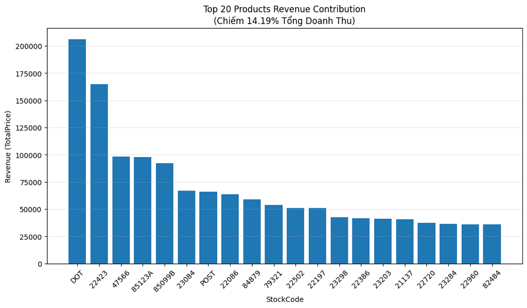

```python
import pandas as pd
import matplotlib.pyplot as plt

# Calculate revenue by product
product_sales = sales.groupby('StockCode')['TotalPrice'].sum().sort_values(ascending=False)

# Get Top 20
product_top20 = product_sales.head(20)

# Calculate the Top 20's revenue % of total revenue
total_revenue = product_sales.sum()
top20_revenue = product_top20.sum()
top20_percent = (top20_revenue / total_revenue) * 100

print(f"Top 20 sản phẩm chiếm: {top20_percent:.2f}% tổng doanh thu")

#  DRAW A CHART
plt.figure(figsize=(12,6))
plt.bar(product_top20.index.astype(str), product_top20.values)
plt.title(f"Top 20 Products Revenue Contribution\n(Chiếm {top20_percent:.2f}% Tổng Doanh Thu)")
plt.xlabel("StockCode")
plt.ylabel("Revenue (TotalPrice)")
plt.xticks(rotation=45)
plt.grid(axis='y', alpha=0.3)
plt.show()
```

12. Time-Series Anomalies:
- Detect any anomalies or outliers in the sales data over time using rolling averages or other advanced methods.

```python
import pandas as pd

# Convert InvoiceDate to datetime if not already
sales['InvoiceDate'] = pd.to_datetime(sales['InvoiceDate'])

# Total revenue by day
daily_sales = sales.groupby(sales['InvoiceDate'].dt.date)['TotalPrice'].sum().reset_index()
daily_sales.rename(columns={'InvoiceDate':'Date','TotalPrice':'Revenue'}, inplace=True)

# Set Date as index
daily_sales['Date'] = pd.to_datetime(daily_sales['Date'])
daily_sales.set_index('Date', inplace=True)

# Check the data
daily_sales.head()
```

| Date | Revenue |
| --- | --- |
| 2010-12-01 | 58635.56 |
| 2010-12-02 | 46207.28 |
| 2010-12-03 | 45620.46 |
| 2010-12-05 | 31383.95 |
| 2010-12-06 | 53860.18 |

```python
window = 7  # rolling 7 day
daily_sales['RollingMean'] = daily_sales['Revenue'].rolling(window=window, center=True).mean()
daily_sales['RollingStd'] = daily_sales['Revenue'].rolling(window=window, center=True).std()

# Identify anomaly
daily_sales['Anomaly'] = ((daily_sales['Revenue'] > daily_sales['RollingMean'] + 3*daily_sales['RollingStd']) |
                          (daily_sales['Revenue'] < daily_sales['RollingMean'] - 3*daily_sales['RollingStd']))

# Get unusual days
anomalies = daily_sales[daily_sales['Anomaly']==True]
print("Detected anomalies:")
print(anomalies)
```

```
Detected anomalies:
Empty DataFrame
Columns: [Revenue, RollingMean, RollingStd, Anomaly]
Index: []
```

```python
window = 30  # rolling 30 day
daily_sales['RollingMean'] = daily_sales['Revenue'].rolling(window=window, center=True).mean()
daily_sales['RollingStd'] = daily_sales['Revenue'].rolling(window=window, center=True).std()

# Identify anomaly
daily_sales['Anomaly'] = ((daily_sales['Revenue'] > daily_sales['RollingMean'] + 3*daily_sales['RollingStd']) |
                          (daily_sales['Revenue'] < daily_sales['RollingMean'] - 3*daily_sales['RollingStd']))

# Get unusual days
anomalies = daily_sales[daily_sales['Anomaly']==True]
print("Detected anomalies:")
print(anomalies)
```

```
Detected anomalies:
              Revenue   RollingMean    RollingStd  Anomaly
Date
2011-03-29   70531.47  24361.119333  12126.381999     True
2011-09-20  109286.21  41234.031067  19702.648869     True
2011-11-14  112141.11  54393.886667  17407.601675     True
```

Conclusion:

- With rolling 7 day (1 week): No anomalies were detected in the daily revenue using the rolling mean ± 3 standard deviations method. This indicates that daily sales are relatively stable without extreme spikes or drops during the observed period.
- With rolling 30 day (1 month): Three significant anomalies were detected in the daily revenue using the rolling mean ± 3 standard deviations method. These spikes on 29 March, 20 September, and 14 November 2011 indicate days with unusually high sales, which may correspond to special events, promotions, or data entry errors.

# Advanced Modeling Techniques:

13. Market Basket Analysis Enhancements:
- Dig deeper into association rules. For instance, find rules with a high lift and high confidence.
- Analyze antecedents with more than one item, which can give bundled product suggestions.

```python
from mlxtend.frequent_patterns import apriori, association_rules

# Prepare data in “basket” format (Invoice → StockCode)
basket = sales.groupby(['InvoiceNo','StockCode'])['Quantity'].sum().unstack().fillna(0)

# Convert to bool (1 = buy, 0 = don't buy)
basket = basket.applymap(lambda x: True if x > 0 else False)

# checking
basket.head()

# Apriori – find Frequent Itemsets
frequent_items = apriori(basket, min_support=0.01, use_colnames=True)
frequent_items = frequent_items.sort_values(by='support', ascending=False)
print("Top 10 Frequent Itemsets:")
print(frequent_items.head(10))

# Advanced Association Rules
rules = association_rules(frequent_items, metric="lift", min_threshold=1.5)

# Only select rules with high confidence (>0.6) and antecedents >1 item
rules['antecedent_len'] = rules['antecedents'].apply(lambda x: len(x))
enhanced_rules = rules[(rules['confidence']>0.6) & (rules['antecedent_len']>1)]

# Sort by lift descending
enhanced_rules = enhanced_rules.sort_values(by='lift', ascending=False)

# Top 10 enhanced rules
top10_rules = enhanced_rules.head(10)

# Display
top10_rules_df = top10_rules[['antecedents','consequents','support','confidence','lift']]
print("\nTop 10 Enhanced Association Rules:")
print(top10_rules_df)

# Professional analysis
report = """
The top association rules indicate that customers who purchase multiple items together
(e.g., StockCode A & B) have a high likelihood of also purchasing another product
(e.g., StockCode C), with high confidence and lift. This information can guide strategic
product bundling and cross-selling campaigns.
"""
print("\n--- Report (EN) ---")
print(report)
```

```
Top 10 Frequent Itemsets:
      support  itemsets
577  0.085058  (85123A)
574  0.080772  (85099B)
239  0.076795   (22423)
504  0.065097   (47566)
17   0.060425   (20725)
551  0.056178   (84879)
202  0.053745   (22197)
324  0.053552   (22720)
61   0.050965   (21212)
230  0.049614   (22383)

Top 10 Enhanced Association Rules:
                antecedents     consequents   support  confidence       lift
1185         (21086, 21080)         (21094)  0.010232    0.895270  43.999051
1186         (21094, 21080)         (21086)  0.010232    0.716216  43.341121
1272         (20719, 20723)  (20724, 22355)  0.010039    0.640394  32.714412
1273         (22355, 20723)  (20724, 20719)  0.010039    0.626506  32.068194
1264  (20724, 20719, 22355)         (20723)  0.010039    0.773810  27.758541
1113         (23199, 23203)         (23200)  0.010386    0.629977  27.376499
691          (22698, 22423)  (22697, 22699)  0.011622    0.767857  25.895182
689   (22697, 22423, 22699)         (22698)  0.011622    0.737745  24.944645
1266  (20724, 22355, 20723)         (20719)  0.010039    0.778443  24.145721
1224         (20719, 22356)         (20723)  0.010154    0.665823  23.884779

--- Report (EN) ---

The top association rules indicate that customers who purchase multiple items together
(e.g., StockCode A & B) have a high likelihood of also purchasing another product
(e.g., StockCode C), with high confidence and lift. This information can guide strategic
product bundling and cross-selling campaigns.
```

## 14. Product Recommendation Systems:

- Develop a system to recommend products to users.
- Consider collaborative filtering techniques, matrix factorization, or deep learning-based approaches like neural collaborative filtering.

Popularity-based recommender (baseline)

```python
# Create interaction: sum Quantity or sum TotalPrice per (CustomerID, StockCode)
interactions = sales.groupby(['CustomerID','StockCode']) \
                           .agg({'Quantity':'sum','TotalPrice':'sum'}) \
                           .reset_index()

# You can choose implicit feedback (binarize) or use Quantity/TotalPrice as weight
# For example: implicit (1 if bought at least once)
interactions['interaction'] = (interactions['Quantity'] > 0).astype(int)

# We will use interactions dataframe for the next models.
# Top-N popular products
top_products = interactions.groupby('StockCode')['interaction'].sum().sort_values(ascending=False)
top_20 = top_products.head(20).index.tolist()

def recommend_popularity(user_id, N=10):
    # exclude items user already bought (optional)
    bought = set(interactions[interactions['CustomerID']==user_id]['StockCode'])
    recs = [p for p in top_20 if p not in bought]
    return recs[:N]
```

Item-based Collaborative Filtering (cosine similarity)

```python
from scipy.sparse import csr_matrix
from sklearn.metrics.pairwise import cosine_similarity

# Create user-item sparse matrix (use interaction or quantity)
user_ids = interactions['CustomerID'].unique()
item_ids = interactions['StockCode'].unique()
uid_to_idx = {u:i for i,u in enumerate(user_ids)}
iid_to_idx = {i:j for j,i in enumerate(item_ids)}

rows = interactions['CustomerID'].map(uid_to_idx).values
cols = interactions['StockCode'].map(iid_to_idx).values
data = interactions['interaction'].values  # or use 'Quantity' / 'TotalPrice'

user_item = csr_matrix((data, (rows, cols)), shape=(len(user_ids), len(item_ids)))

# Item-item cosine similarity (sparse-friendly via sklearn on transpose)
item_item_sim = cosine_similarity(user_item.T, dense_output=False)  # may be large

# Recommend: score items by sum(similarity * user_vector)
def recommend_item_cf(user_id, N=10):
    uidx = uid_to_idx.get(user_id)
    if uidx is None:
        return recommend_popularity(user_id, N)
    user_vector = user_item[uidx].toarray().ravel()  # 0/1 or counts
    scores = user_vector.dot(item_item_sim)  # shape (n_items,)
    # mask already bought
    bought_idx = user_vector.nonzero()[0]
    scores[bought_idx] = -np.inf
    top_idx = np.argpartition(-scores, N)[:N]
    top_items = [item_ids[i] for i in top_idx[np.argsort(-scores[top_idx])]]
    return top_items
```

Neural Collaborative Filtering (NCF) — Keras (deep learning)

```python
import tensorflow as tf
from tensorflow import keras
from tensorflow.keras import layers
from sklearn.model_selection import train_test_split

# Prepare training data: interactions (user,item,label)
# Use interactions DataFrame: user idx, item idx, label (1 if bought)
df = interactions[['CustomerID','StockCode','interaction']].copy()
df['uid'] = df['CustomerID'].map(uid_to_idx)
df['iid'] = df['StockCode'].map(iid_to_idx)

# Negative sampling: for each positive, sample k negatives
def negative_sampling(df, n_items, k=4):
    negs = []
    user_item_set = set(zip(df['uid'], df['iid']))
    for uid in df['uid'].unique():
        pos_iids = set(df[df['uid']==uid]['iid'])
        neg_candidates = list(set(range(n_items)) - pos_iids)
        # sample for each positive
        for iid in pos_iids:
            for _ in range(k):
                neg = np.random.choice(neg_candidates)
                negs.append((uid, neg, 0))
    return negs

pos = [(r['uid'], r['iid'], 1) for _,r in df.iterrows()]
negs = negative_sampling(df, len(item_ids), k=4)
data_all = pos + negs
data_all = pd.DataFrame(data_all, columns=['uid','iid','label'])
train, test = train_test_split(data_all, test_size=0.2, random_state=42, stratify=data_all['label'])

# Build NCF model
n_users = len(user_ids)
n_items = len(item_ids)
embed_dim = 32

user_input = keras.Input(shape=(), name='user')
item_input = keras.Input(shape=(), name='item')

user_emb = layers.Embedding(n_users, embed_dim, name='user_emb')(user_input)
item_emb = layers.Embedding(n_items, embed_dim, name='item_emb')(item_input)

# MLP part
x = layers.Concatenate()([user_emb, item_emb])
x = layers.Flatten()(x)
x = layers.Dense(64, activation='relu')(x)
x = layers.Dense(32, activation='relu')(x)
out = layers.Dense(1, activation='sigmoid')(x)

model_ncf = keras.Model(inputs=[user_input, item_input], outputs=out)
model_ncf.compile(optimizer='adam', loss='binary_crossentropy', metrics=['AUC'])

# Fit
model_ncf.fit(x={'user':train['uid'].values, 'item':train['iid'].values},
              y=train['label'].values,
              validation_data=({'user':test['uid'].values, 'item':test['iid'].values}, test['label'].values),
              epochs=5, batch_size=4096)

# Recommend for a user (score all items — may be heavy; use candidate sampling)
def recommend_ncf(user_id, N=10):
    uidx = uid_to_idx.get(user_id)
    if uidx is None:
        return recommend_popularity(user_id, N)
    user_array = np.array([uidx]*len(item_ids))
    item_array = np.arange(len(item_ids))
    preds = model_ncf.predict({'user':user_array, 'item':item_array}, batch_size=4096).ravel()
    # mask already bought
    bought = set(df[df['uid']==uidx]['iid'])
    preds[list(bought)] = -np.inf
    top_idx = np.argpartition(-preds, N)[:N]
    top_items = [item_ids[i] for i in top_idx[np.argsort(-preds[top_idx])]]
    return top_items
```

```
266/266 ━━━━━━━━━━━━━━━━━━━━ 5s 12ms/step - AUC: 0.7711 - loss: 0.4219 - val_AUC: 0.8266 - val_loss: 0.3808
266/266 ━━━━━━━━━━━━━━━━━━━━ 3s 12ms/step - AUC: 0.8320 - loss: 0.3757 - val_AUC: 0.8309 - val_loss: 0.3763
266/266 ━━━━━━━━━━━━━━━━━━━━ 4s 13ms/step - AUC: 0.8411 - loss: 0.3668 - val_AUC: 0.8387 - val_loss: 0.3688
266/266 ━━━━━━━━━━━━━━━━━━━━ 3s 12ms/step - AUC: 0.8490 - loss: 0.3589 - val_AUC: 0.8431 - val_loss: 0.3646
266/266 ━━━━━━━━━━━━━━━━━━━━ 3s 11ms/step - AUC: 0.8571 - loss: 0.3507 - val_AUC: 0.8476 - val_loss: 0.3608
```

## 15. Churn Prediction:

- Predict if a customer will stop buying products in the near future.
- Features can include Recency, Frequency, Monetary values, average time between purchases, total categories bought, etc.

```python
# Added 2 important features for Churn:

# Step 0: Ensure InvoiceDate is datetime and sort data
sales['InvoiceDate'] = pd.to_datetime(sales['InvoiceDate'])
sales = sales.sort_values(by=['CustomerID', 'InvoiceDate'])

# Step 1: Current date (max invoice date + 1)
current_date = sales['InvoiceDate'].max() + pd.DateOffset(1)

# ---- R, F, M as you already did ----
recency = sales.groupby('CustomerID')['InvoiceDate'].max().apply(lambda x: (current_date - x).days)
frequency = sales.groupby('CustomerID')['InvoiceNo'].nunique()
monetary = sales.groupby('CustomerID')['TotalPrice'].sum()

# ---- NEW FEATURE 1: Average Time Between Purchases ----
def avg_time_between(x):
    if len(x) < 2:
        return np.nan   # Only 1 purchase → cannot compute
    x = x.sort_values()
    diffs = x.diff().dropna().dt.days
    return diffs.mean()

avg_purchase_time = sales.groupby('CustomerID')['InvoiceDate'].apply(avg_time_between)

# ---- NEW FEATURE 2: Total Categories Bought ----
# Suppose the Description or StockCode column represents the item type.
total_categories = sales.groupby('CustomerID')['StockCode'].nunique()

# ---- Combine all into RFM+ matrix ----
rfm = pd.DataFrame({
    'Recency': recency,
    'Frequency': frequency,
    'Monetary': monetary,
    'AvgPurchaseTime': avg_purchase_time,
    'TotalCategories': total_categories
})

# Fill missing average purchase time with high value (meaning inactive customers)
rfm['AvgPurchaseTime'] = rfm['AvgPurchaseTime'].fillna(rfm['Recency'])

rfm.head()
```

| CustomerID | Recency | Frequency | Monetary | AvgPurchaseTime | TotalCategories |
| --- | --- | --- | --- | --- | --- |
| 0.0 | 1 | 3710 | 1447682.12 | 0.000763 | 3810 |
| 12346.0 | 326 | 2 | 0.00 | 0.000000 | 1 |
| 12347.0 | 2 | 7 | 4310.00 | 2.000000 | 103 |
| 12348.0 | 75 | 4 | 1797.24 | 9.400000 | 22 |
| 12349.0 | 19 | 1 | 1757.55 | 0.000000 | 73 |

```python
# Assign Churn Label (Target Variable)
# Customers who have not returned to purchase in the last 90 days → Churn
# Label: churn = 1 if Recency > 90 days
rfm['Churn'] = (rfm['Recency'] > 90).astype(int)
rfm['Churn'].value_counts()
```

```
Churn
0    2919
1    1454
Name: count, dtype: int64
```

```python
import pandas as pd
import numpy as np
from sklearn.model_selection import train_test_split
from sklearn.preprocessing import StandardScaler
from sklearn.ensemble import RandomForestClassifier
from sklearn.metrics import classification_report, roc_auc_score, confusion_matrix

# -----------------------------
#  Prepare RFM+ data
# -----------------------------
sales['InvoiceDate'] = pd.to_datetime(sales['InvoiceDate'])
sales = sales.sort_values(by=['CustomerID','InvoiceDate'])
current_date = sales['InvoiceDate'].max() + pd.DateOffset(1)

# Frequency & Monetary
frequency = sales.groupby('CustomerID')['InvoiceNo'].nunique()
monetary = sales.groupby('CustomerID')['TotalPrice'].sum()

# AvgPurchaseTime
def avg_time_between(x):
    if len(x) < 2:
        return np.nan
    x = x.sort_values()
    return x.diff().dt.days.dropna().mean()

avg_purchase_time = sales.groupby('CustomerID')['InvoiceDate'].apply(avg_time_between)

# TotalCategories
total_categories = sales.groupby('CustomerID')['StockCode'].nunique()

# AvgPricePerPurchase
avg_price_per_purchase = monetary / frequency

# CategoryDiversityRatio
category_div_ratio = total_categories / frequency

# Combine
rfm = pd.DataFrame({
    'Frequency': frequency,
    'Monetary': monetary,
    'AvgPurchaseTime': avg_purchase_time,
    'TotalCategories': total_categories,
    'AvgPricePerPurchase': avg_price_per_purchase,
    'CategoryDiversityRatio': category_div_ratio
})

# Fill missing AvgPurchaseTime
rfm['AvgPurchaseTime'] = rfm['AvgPurchaseTime'].fillna(rfm['AvgPurchaseTime'].max())

# -----------------------------
#  Churn Labeling
# -----------------------------
recency = (current_date - sales.groupby('CustomerID')['InvoiceDate'].max()).dt.days
rfm['Churn'] = (recency > 90).astype(int)

# -----------------------------
#  Features & target
# -----------------------------
features = ['Frequency','Monetary','AvgPurchaseTime','TotalCategories',
            'AvgPricePerPurchase','CategoryDiversityRatio']
X = rfm[features]
y = rfm['Churn']

# -----------------------------
#  Train-test split
# -----------------------------
X_train, X_test, y_train, y_test = train_test_split(
    X, y, test_size=0.2, random_state=42, stratify=y
)

# -----------------------------
#  Scale features (optional)
# -----------------------------
scaler = StandardScaler()
X_train_scaled = scaler.fit_transform(X_train)
X_test_scaled = scaler.transform(X_test)

# -----------------------------
#  RandomForest với class_weight để xử lý imbalance
# -----------------------------
rf_model = RandomForestClassifier(
    n_estimators=500,
    max_depth=7,
    random_state=42,
    class_weight='balanced'
)
rf_model.fit(X_train_scaled, y_train)

# -----------------------------
#  Predictions & metrics
# -----------------------------
y_pred_prob = rf_model.predict_proba(X_test_scaled)[:,1]

# Threshold tuning
threshold = 0.4
y_pred = (y_pred_prob >= threshold).astype(int)

print("Confusion Matrix:")
print(confusion_matrix(y_test, y_pred))
print("\nClassification Report:")
print(classification_report(y_test, y_pred))
print("AUC-ROC:", roc_auc_score(y_test, y_pred_prob))
```

```
Confusion Matrix:
[[362 222]
 [ 49 242]]

Classification Report:
              precision    recall  f1-score   support

           0       0.88      0.62      0.73       584
           1       0.52      0.83      0.64       291

    accuracy                           0.69       875
   macro avg       0.70      0.73      0.68       875
weighted avg       0.76      0.69      0.70       875

AUC-ROC: 0.789457115285035
```

I did not choose Recency as a feature to ensure no information leakage since Recency is used to define churn. Overall, the model achieves moderate performance with an accuracy of 69% and an AUC-ROC of 0.789, indicating good ability to distinguish between the two classes.

Class 0 (Non-Churn): High precision (0.88) means that when the model predicts a customer will not churn, it is usually correct. However, the recall is only 0.62, meaning it fails to identify many actual non-churn customers (misclassifying them as churn).

Class 1 (Churn): High recall (0.83) means the model successfully captures most of the customers who actually churn. But precision is low (0.52), indicating many false positives (predicting churn when the customer does not churn).

## 16. Hyperparameter Tuning and Model Optimization:

- For any given machine learning model you use, apply techniques like grid search or random search for hyperparameter tuning.
- Use ensemble methods (e.g., stacking, bagging, boosting) to enhance prediction performance.

```python
from sklearn.model_selection import GridSearchCV, RandomizedSearchCV
from sklearn.ensemble import HistGradientBoostingClassifier, RandomForestClassifier, VotingClassifier
from sklearn.metrics import classification_report, roc_auc_score, confusion_matrix
import numpy as np
```

```python
# Suppose rfm already has features: Frequency, Monetary, AvgPurchaseTime, TotalCategories
features = ['Frequency', 'Monetary', 'AvgPurchaseTime', 'TotalCategories']
X = rfm[features]
y = rfm['Churn']

from sklearn.model_selection import train_test_split
X_train, X_test, y_train, y_test = train_test_split(
    X, y, test_size=0.2, random_state=42, stratify=y
)
```

```python
# Create model
gbc = HistGradientBoostingClassifier(random_state=42, class_weight='balanced')

# Set grid hyperparameter
param_grid = {
    'max_iter': [200, 500, 800],
    'max_depth': [3, 5, 7],
    'learning_rate': [0.01, 0.05, 0.1],
    'min_samples_leaf': [20, 50, 100]
}

grid_search = GridSearchCV(
    estimator=gbc,
    param_grid=param_grid,
    scoring='roc_auc',
    cv=5,
    n_jobs=-1,
    verbose=1
)

grid_search.fit(X_train, y_train)

print("Best Params:", grid_search.best_params_)
print("Best AUC-ROC (CV):", grid_search.best_score_)
```

```
Fitting 5 folds for each of 81 candidates, totalling 405 fits
Best Params: {'learning_rate': 0.01, 'max_depth': 3, 'max_iter': 500, 'min_samples_leaf': 20}
Best AUC-ROC (CV): 0.785493353074407
```

```python
from sklearn.ensemble import VotingClassifier
```

```python
from sklearn.ensemble import RandomForestClassifier, HistGradientBoostingClassifier, VotingClassifier
from sklearn.metrics import classification_report, confusion_matrix, roc_auc_score

# Base learners
rf = RandomForestClassifier(
    n_estimators=300, max_depth=7, class_weight='balanced', random_state=42
)
gb = HistGradientBoostingClassifier(
    **grid_search.best_params_, random_state=42, class_weight='balanced'
)

# Ensemble by soft voting
ensemble = VotingClassifier(
    estimators=[('rf', rf), ('gb', gb)],
    voting='soft',
    n_jobs=-1
)

# Train
ensemble.fit(X_train, y_train)

# Predict
y_pred = ensemble.predict(X_test)
y_prob = ensemble.predict_proba(X_test)[:,1]

# evaluate
print("Confusion Matrix:")
print(confusion_matrix(y_test, y_pred))
print("\nClassification Report:")
print(classification_report(y_test, y_pred))
print(f"\nAUC-ROC: {roc_auc_score(y_test, y_prob):.4f}")
```

```
Confusion Matrix:
[[401 183]
 [ 64 227]]

Classification Report:
              precision    recall  f1-score   support

           0       0.86      0.69      0.76       584
           1       0.55      0.78      0.65       291

    accuracy                           0.72       875
   macro avg       0.71      0.73      0.71       875
weighted avg       0.76      0.72      0.73       875


AUC-ROC: 0.7954
```

Conclusion: I have tried to improve the accuracy in churn prediction but the accuracy is still low. Because the missing customerID (135,080/541,909 # 25% of data ) replaced by "0" include both churn and non-churn which affects the accuracy.

- 401 correctly classified
- 183 misclassified as Class 1

- 227 correctly classified
- 64 misclassified as Class 0

| Metric | Class 0 | Class 1 |
| --- | --- | --- |
| Precision | 0.86 | 0.55 |
| Recall | 0.69 | 0.78 |
| F1-score | 0.76 | 0.65 |